# STATS 506 HW3

Author

Minxuan Chen

Published

October 2, 2023

Github repo: https://github.com/PKUniiiiice/STATS_506

## Problem 1 Vision

### (a)

```stata
. do "K:\STATS_506\STATA\stata_hw3.Do"

. //load data
. cd "K:\STATS_506\STATA\"
K:\STATS_506\STATA

.
. //Part a ---------------------------------------------------------------------

.
. //import first
. import sasxport5 VIX_D.XPT, clear

. //save as dta
. save "K:\STATS_506\STATA\VIX_D.dta"
file K:\STATS_506\STATA\VIX_D.dta saved

. //import second
. import sasxport5 DEMO_D.XPT, clear

. // Merge the second dataset using the SEQN variable
. merge 1:1 seqn using "K:\STATS_506\STATA\VIX_D.dta"

    Result                      Number of obs
    -----------------------------------------
    Not matched                         3,368
        from master                     3,368  (_merge==1)
        from using                          0  (_merge==2)

    Matched                             6,980  (_merge==3)
    -----------------------------------------

.
. // Keep only the matched records
. keep if _merge == 3
(3,368 observations deleted)

.
. //total sample size
. di _N
6980

.
. //End of Part a --------------------------------------------------------------

.
```

### (b)

In this part, we refer to these websites for help.  
https://grodri.github.io/stata/tables  
https://www.stata.com/manuals/tables.pdf

```stata
. //Part b ---------------------------------------------------------------------

. //We use the variable 'VIX220 - Glasses/contact lenses worn for distance' (viq
> 220)
. //and  'RIDAGEYR - Age at Screening Adjudicated - Recode' (ridageyr)
.
. egen age_interval = cut(ridageyr), at(0(10)90) label

. table age_interval viq220, missing statistic(percent, across(viq220)) statisti
> c(frequency)

-----------------------------------------------------------------
              |      Glasses/contact lenses worn for distance
              |         1         2        9         .      Total
--------------+--------------------------------------------------
age_interval  |
  10-         |
    Percent   |     30.36     64.25               5.39     100.00
    Frequency |       670     1,418                119      2,207
  20-         |
    Percent   |     29.97     61.80     0.20      8.03     100.00
    Frequency |       306       631        2        82      1,021
  30-         |
    Percent   |     32.89     58.80               8.31     100.00
    Frequency |       269       481                 68        818
  40-         |
    Percent   |     35.09     59.75               5.15     100.00
    Frequency |       286       487                 42        815
  50-         |
    Percent   |     53.09     43.42               3.49     100.00
    Frequency |       335       274                 22        631
  60-         |
    Percent   |     59.30     36.01               4.69     100.00
    Frequency |       392       238                 31        661
  70-         |
    Percent   |     63.75     31.56               4.69     100.00
    Frequency |       299       148                 22        469
  80-         |
    Percent   |     58.10     28.77              13.13     100.00
    Frequency |       208       103                 47        358
  Total       |
    Percent   |     39.61     54.15     0.03      6.20     100.00
    Frequency |     2,765     3,780        2       433      6,980
-----------------------------------------------------------------

. quietly collect layout (age_interval) (viq220#result[percent] viq220#result[fr
> equency])

. //If only want to see first column
. //https://grodri.github.io/stata/tables https://www.stata.com/manuals/tables.p
> df
.
. //percent
. collect layout (age_interval) (viq220[1]#result[percent] viq220[.m]#result[fre
> quency])

Collection: Table
      Rows: age_interval
   Columns: viq220[1]#result[percent] viq220[.m]#result[frequency]
   Table 1: 10 x 2

----------------------------------------------------------
             |   Glasses/contact lenses worn for distance
             |                    1                  Total
             |              Percent              Frequency
-------------+--------------------------------------------
age_interval |
  10-        |                30.36                  2,207
  20-        |                29.97                  1,021
  30-        |                32.89                    818
  40-        |                35.09                    815
  50-        |                53.09                    631
  60-        |                59.30                    661
  70-        |                63.75                    469
  80-        |                58.10                    358
  Total      |                39.61                  6,980
----------------------------------------------------------

.
. //End of Part b --------------------------------------------------------------
```

### (c)

In this part, we refer to these websites for help.  
https://www.stata.com/manuals/rlogistic.pdf  
https://repec.org/bocode/e/estout/hlp_esttab.html

In the logistic regression models, we regard gender and race as categorical variables, while age and Poverty Income ratio as continuous variables.

```stata
.
. //Part c ---------------------------------------------------------------------

. //For age, we use ridageyr
. //For race, we use ridreth1
. //For gender, we use riagendr
. //For Poverty Income ratio, we use indfmpir
. //We first check how many missing values are in these variables
. misstable summarize ridageyr ridreth1 riagendr indfmpir viq220
                                                               Obs<.
                                                +------------------------------
               |                                | Unique
      Variable |     Obs=.     Obs>.     Obs<.  | values        Min         Max
  -------------+--------------------------------+------------------------------
      indfmpir |       342               6,638  |    435          0           5
        viq220 |       433               6,547  |      3          1           9
  -----------------------------------------------------------------------------

.
. //It seems that the proportion of missing value is not large, about 10%, so we
>  choose to directly delete them
. drop if missing(indfmpir) | missing(viq220)
(731 observations deleted)

. misstable summarize ridageyr ridreth1 riagendr indfmpir viq220
(variables nonmissing or string)

.
. ///We treat viq220==1 as "Yes, wear", and all other values as "No, don't wear"
> //recode viq220
. recode viq220 (1=1) (else=0), generate(viq220_bin)
(3,594 differences between viq220 and viq220_bin)

.
. //ref https://www.stata.com/manuals/rlogistic.pdf
. //Note that race and gender shoule be categorical variables and age and PIR ar
> e continuous variables
.
.
. // Fit the first logistic regression model (age only)
. logistic viq220_bin ridageyr

Logistic regression                                     Number of obs =  6,249
                                                        LR chi2(1)    = 403.63
                                                        Prob > chi2   = 0.0000
Log likelihood = -4058.8462                             Pseudo R2     = 0.0474

------------------------------------------------------------------------------
  viq220_bin | Odds ratio   Std. err.      z    P>|z|     [95% conf. interval]
-------------+----------------------------------------------------------------
    ridageyr |   1.024531   .0012702    19.55   0.000     1.022044    1.027023
       _cons |   .2923673    .015974   -22.51   0.000     .2626769    .3254136
------------------------------------------------------------------------------
Note: _cons estimates baseline odds.

.
. // Store the results
. eststo model1

.
. // Fit the second logistic regression model (age, race, gender)
. logistic viq220_bin ridageyr i.ridreth1 i.riagendr

Logistic regression                                     Number of obs =  6,249
                                                        LR chi2(6)    = 584.06
                                                        Prob > chi2   = 0.0000
Log likelihood = -3968.6291                             Pseudo R2     = 0.0685

------------------------------------------------------------------------------
  viq220_bin | Odds ratio   Std. err.      z    P>|z|     [95% conf. interval]
-------------+----------------------------------------------------------------
    ridageyr |     1.0226   .0013241    17.26   0.000     1.020009    1.025199
             |
    ridreth1 |
          2  |   1.169508   .1959093     0.93   0.350     .8421995    1.624021
          3  |   1.895064   .1363291     8.89   0.000     1.645846    2.182019
          4  |   1.293781   .1015763     3.28   0.001     1.109257    1.509002
          5  |   1.885095   .2612655     4.57   0.000     1.436681    2.473465
             |
  2.riagendr |   1.650228   .0891912     9.27   0.000     1.484357    1.834634
       _cons |   .1650721   .0132324   -22.47   0.000     .1410718    .1931555
------------------------------------------------------------------------------
Note: _cons estimates baseline odds.

.
. eststo model2

.
. // Fit the third logistic regression model (age, race, gender, Poverty Income
> ratio)
. logistic viq220_bin ridageyr i.ridreth1 i.riagendr indfmpir

Logistic regression                                     Number of obs =  6,249
                                                        LR chi2(7)    = 625.24
                                                        Prob > chi2   = 0.0000
Log likelihood = -3948.0387                             Pseudo R2     = 0.0734

------------------------------------------------------------------------------
  viq220_bin | Odds ratio   Std. err.      z    P>|z|     [95% conf. interval]
-------------+----------------------------------------------------------------
    ridageyr |    1.02245    .001324    17.15   0.000     1.019858    1.025048
             |
    ridreth1 |
          2  |   1.124663   .1892328     0.70   0.485     .8087261    1.564023
          3  |   1.652417    .124123     6.69   0.000     1.426201    1.914514
          4  |    1.23222   .0975979     2.64   0.008      1.05504    1.439155
          5  |    1.70633   .2391229     3.81   0.000     1.296513    2.245688
             |
  2.riagendr |   1.673821   .0908852     9.49   0.000     1.504841    1.861777
    indfmpir |    1.12011   .0198248     6.41   0.000      1.08192    1.159647
       _cons |   .1330474   .0116811   -22.97   0.000     .1120144    .1580298
------------------------------------------------------------------------------
Note: _cons estimates baseline odds.

.
. eststo model3

.
. // Create a table to display results using esttab
. // https://repec.org/bocode/e/estout/hlp_esttab.html
. esttab model1 model2 model3, ///
>         con ///
>         not ///
>     stats(N r2_p aic) ///
>     eform ///
>     varwidth(15) ///
>     title("Logistic Regression Results") ///
>     label

Logistic Regression Results
---------------------------------------------------------------
                         (1)             (2)             (3)
                RECODE of ~c    RECODE of ~c    RECODE of ~c
---------------------------------------------------------------
RECODE of viq~c
Age at Screen~R        1.025***        1.023***        1.022***
Race/Ethnicit~1                            1               1
Race/Ethnicit~2                        1.170           1.125
Race/Ethnicit~3                        1.895***        1.652***
Race/Ethnicit~4                        1.294**         1.232**
Race/Ethnicit~5                        1.885***        1.706***
Gender=1                                   1               1
Gender=2                               1.650***        1.674***
Family PIR                                             1.120***
Constant               0.292***        0.165***        0.133***
---------------------------------------------------------------
N                       6249            6249            6249
r2_p                  0.0474          0.0685          0.0734
aic                   8121.7          7951.3          7912.1
---------------------------------------------------------------
Exponentiated coefficients
* p<0.05, ** p<0.01, *** p<0.001

.
. //End of Part c --------------------------------------------------------------
```

### (d)

In the output table, the odds ratio of `Gender=2` is significant, therefore, the odds of men and women being wears of glasses/contact lenses for distance vision differs.

From the chi-squared test result, p-value is 0.000, therefore we conclude that gender and wearing or not are not independent, in other words, the proportion of wearers of glasses/contact lenses for distance vision differs between men and women.

```stata
. //Part d ---------------------------------------------------------------------

.
. //Note that in the output table, the odds ratio of Gender=2 is significant, th
> erefore,
. //the odds of men and women being wears of glasses/contact lenses for distance
>  vision differs.
.
. //We use chi-square test (Pearson's Chi-Squared Test of Independence)
. tabulate riagendr viq220_bin, chi2

           |   RECODE of viq220
           |   (Glasses/contact
           |    lenses worn for
           |       distance)
    Gender |         0          1 |     Total
-----------+----------------------+----------
         1 |     1,919      1,134 |     3,053
         2 |     1,675      1,521 |     3,196
-----------+----------------------+----------
     Total |     3,594      2,655 |     6,249

          Pearson chi2(1) =  69.7397   Pr = 0.000

.
. //From the result, p-value is 0.000, therefore we conclude that gender and wea
> ring or not
. //are not independent, in other words, the proportion of wearers of glasses/co
> ntact lenses for distance vision differs between men and women
.
. //End of Part d --------------------------------------------------------------

end of do-file
```

## Problem 2 Sakila

### (a)

```r
library(DBI)
library(RSQLite)
sakila <- dbConnect(RSQLite::SQLite(), "sakila_working.db")

#list tables contained in the database
dbListTables(sakila)
```

```
 [1] "actor"                  "address"                "category"
 [4] "city"                   "country"                "customer"
 [7] "customer_list"          "film"                   "film_actor"
[10] "film_category"          "film_list"              "film_text"
[13] "inventory"              "language"               "payment"
[16] "rental"                 "sales_by_film_category" "sales_by_store"
[19] "staff"                  "staff_list"             "store"
```

```r
#Aside from English, what language is most common for films?
dbGetQuery(sakila, "
SELECT b.name as name, COUNT(*) as film_num
  FROM film a
    LEFT JOIN language b ON a.language_id = b.language_id
  WHERE b.name <> 'English'
  GROUP BY b.name
  ORDER BY -film_num
  LIMIT 1
")
```

```
[1] name     film_num
<0 rows> (or 0-length row.names)
```

### (b)

```r
#SQL+R
film_cat <- dbReadTable(sakila, "film_category")
category <- dbReadTable(sakila, "category")

#merge two dataframe by category_id
t1 <- merge(film_cat, category, by=c("category_id"))

#aggregate to count how many
result <- aggregate(film_id ~ name, data = t1,
                    FUN = function(x) length(unique(x)))
#sort to get the most common
result <- result[order(result$film_id, decreasing=TRUE), ]
result
```

```
          name film_id
15      Sports      74
9      Foreign      73
8       Family      69
6  Documentary      68
2    Animation      66
1       Action      64
13         New      63
7        Drama      62
10       Games      61
14      Sci-Fi      61
3     Children      60
5       Comedy      58
4     Classics      57
16      Travel      57
11      Horror      56
12       Music      51
```

```r
#pure SQL
dbGetQuery(sakila, "
SELECT b.name as name, COUNT(distinct film_id) as movie_nums
  FROM film_category a
    LEFT JOIN category b ON a.category_id = b.category_id
  GROUP BY b.name
  ORDER BY -movie_nums
")
```

```
          name movie_nums
1       Sports         74
2      Foreign         73
3       Family         69
4  Documentary         68
5    Animation         66
6       Action         64
7          New         63
8        Drama         62
9        Games         61
10      Sci-Fi         61
11    Children         60
12      Comedy         58
13    Classics         57
14      Travel         57
15      Horror         56
16       Music         51
```

Sports is the most common genre in the data, it contains 74 movies.

### (c)

```r
#SQL+R
customer <- dbReadTable(sakila, "customer")
address <- dbReadTable(sakila, "address")
city <- dbReadTable(sakila, "city")
country <- dbReadTable(sakila, "country")

t2 <- merge(customer, address, by="address_id", all.x=TRUE)
t2 <- merge(t2, subset(city, select=-`last_update`),
            by="city_id", all.x=TRUE)
t2 <- merge(t2, subset(country, select=-`last_update`),
            by="country_id", all.x=TRUE)

#aggregate to count how many customers
result2 <- aggregate(customer_id ~ country, data = t2,
                    FUN = function(x) length(unique(x)))
#Identify which country or countries have exactly 9 customers
result2[result2$customer_id == 9, ]
```

```
           country customer_id
101 United Kingdom           9
```

```r
#pure SQL
dbGetQuery(sakila, "
SELECT cty.country as country, COUNT(distinct cus.customer_id) as cus_nums
  FROM customer cus
    LEFT JOIN address addr ON cus.address_id = addr.address_id
    LEFT JOIN city on addr.city_id = city.city_id
    LEFT JOIN country cty on city.country_id = cty.country_id
  GROUP BY cty.country
  HAVING COUNT(distinct cus.customer_id) = 9
")
```

```
         country cus_nums
1 United Kingdom        9
```

United Kingdom has exactly 9 customers.

## Problem 3 US Records

### (a)

```r
library(stringr)
us_500 <- read.csv("us-500.csv")

#proportion of email addresses are hosted at a domain with TLD “.net”?
mean(str_detect(us_500$email, "@\\w*\\.net"))
```

```
[1] 0.14
```

14% email addresses are hosted at a domain with TLD “.net”.

### (b)

```r
#What proportion of email addresses have at least one non alphanumeric character
#the non alphanumeric occurs in two case, before @ or after @
#before @ can be .
#after @, can't be .
mean(str_detect(us_500$email,
                "(^.*[^[:alnum:]]+.*@|@.*[^[:alnum:]@\\.]+.*$)"))
```

```
[1] 0.506
```

50.6% email addresses have at least one non alphanumeric character in them.

### (c)

```r
#all phone numbers
phone_num <- c(us_500$phone1, us_500$phone2)

#extract area code
phone_num <- as.factor(unname(sapply(phone_num,
                                     function(x) substr(x,1,3))))

most_com_area <- names(sort(table(phone_num), decreasing = TRUE)[1])
most_com_area
```

```
[1] "973"
```

The most common area code amongst all phone numbers is “973”.

### (d)

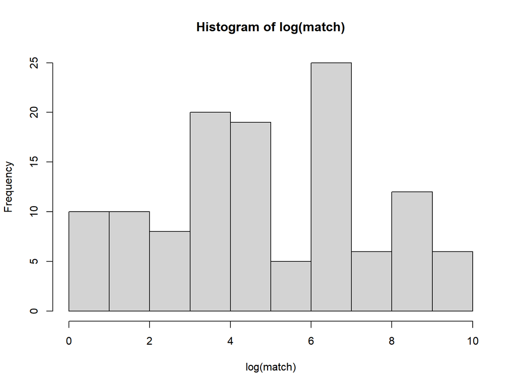

```r
#we first remove all leading/trailing whitespace
addr <- trimws(us_500$address)
#pattern
#after observation, either #number or ' num '
# we prioritize match '#number', if don't match, then we match ' num '

#first
pat <- "(?<=#)\\d+$"
m1 <- str_extract(addr, pat)

#second
pat <- "(?<!^)(?<=[:alpha:] )\\d+\\b"
m2 <- str_extract(addr[is.na(m1)], pat)

#exception
#"83 County Road 437 #8581"
#"9 State Highway 57 #22"
#Although according to the question requirements, 437 and 57 are also APT number, however, according to common sense, they are not.

#now we combine m1 and m2
match <- as.integer(c(m1[!is.na(m1)], m2[!is.na(m2)]))
hist(log(match))
```

### (e)

```r
#extract leading digit
match_lead <- match %/% 10^(floor(log10(match)))

#we use empirical distribution to estimate real distribution
hat_lead_prob <- table(as.factor(match_lead))/length(match_lead)
hat_lead_prob
```

```
         1          2          3          4          5          6          7
0.12396694 0.10743802 0.10743802 0.11570248 0.12396694 0.09090909 0.09917355
         8          9
0.09090909 0.14049587
```

```r
thy_prob <- setNames(c(log10(1+1/1:9)),1:9)
thy_prob
```

```
         1          2          3          4          5          6          7
0.30103000 0.17609126 0.12493874 0.09691001 0.07918125 0.06694679 0.05799195
         8          9
0.05115252 0.04575749
```

It seems that these two distributions are different, so we think the apartment numbers don’t appear to follow Benford’s law. Therefore, they would not pass as real data.

### (f)

```r
#we extract the starting digits as the street number
pat <- "^\\d+\\b"
st_no <- str_extract(addr, pat)

#extract last digit
st_no_last <- as.integer(st_no) %% 10

#we use empirical distribution to estimate real distribution
stno_prob <- table(as.factor(st_no_last))/length(st_no_last)
stno_prob[-1] #remove 0
```

```
    1     2     3     4     5     6     7     8     9
0.082 0.108 0.102 0.106 0.104 0.086 0.112 0.090 0.132
```

```r
thy_prob
```

```
         1          2          3          4          5          6          7
0.30103000 0.17609126 0.12493874 0.09691001 0.07918125 0.06694679 0.05799195
         8          9
0.05115252 0.04575749
```

It seems that these two distributions are different, so we think the street numbers don’t appear to follow Benford’s law. Therefore, they would not pass as real data.